# Imba_data EDA

Zhenyu Zhang

2025-06-13

| 1. raw data pre check |
| --- |

2. Single table EDA（Explore Data Analysis）

2.0 准备工作 type conversion [把离散的数字列变成因子或整数，便于后续绘图与汇总]

2.1 订单 (orders) 按星期 & 小时分布

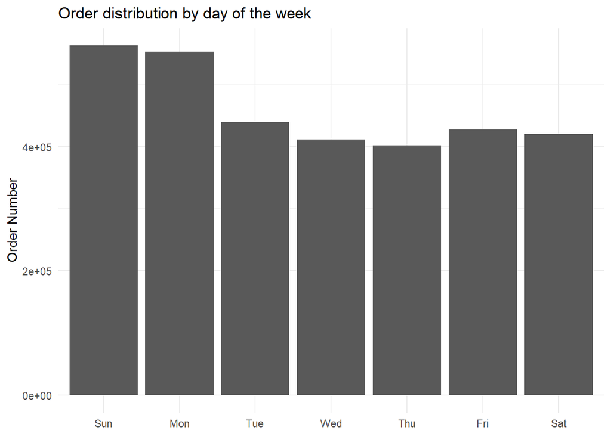

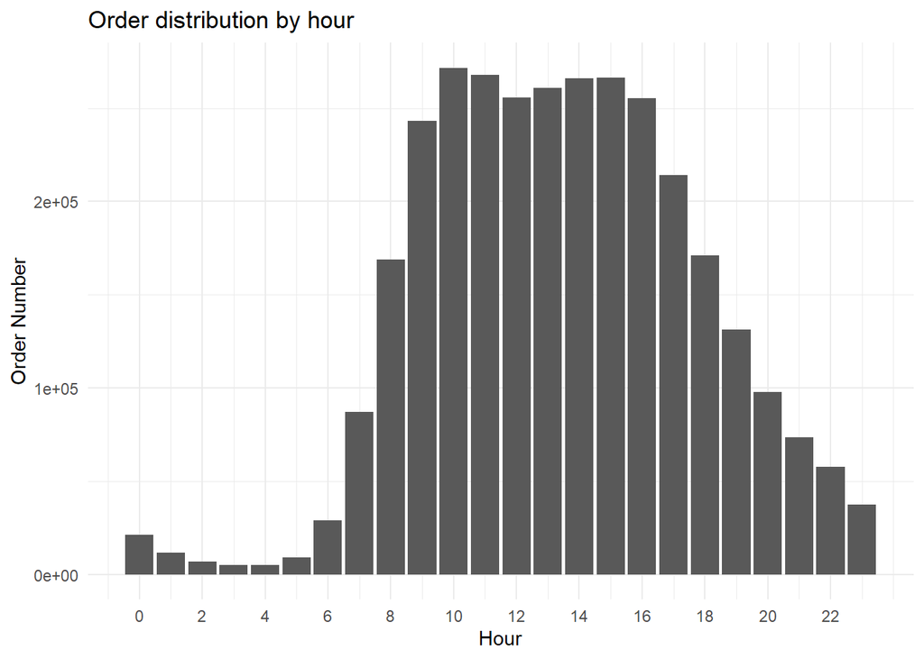

复购周期分布

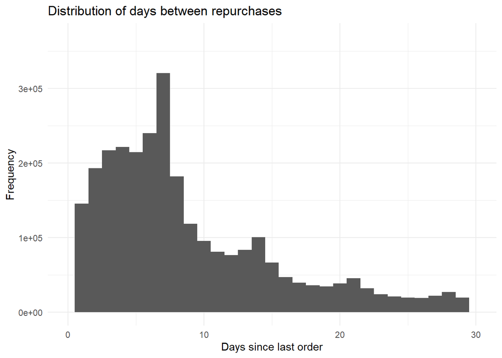

用户下单次数分布

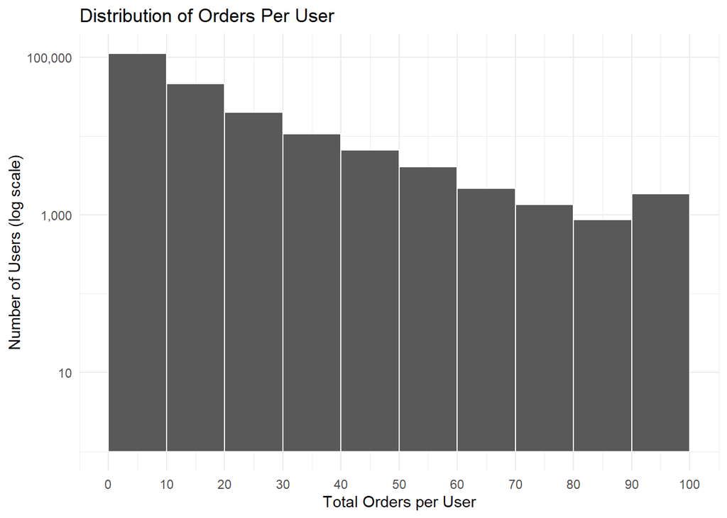

2.2 订单–产品 (order_products)

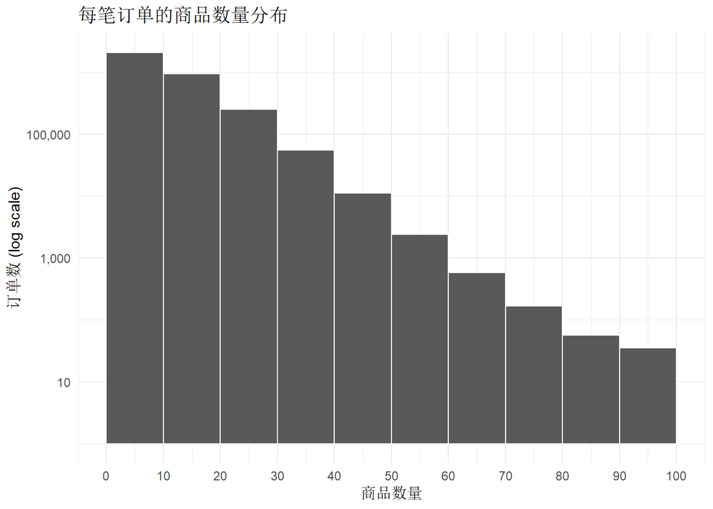

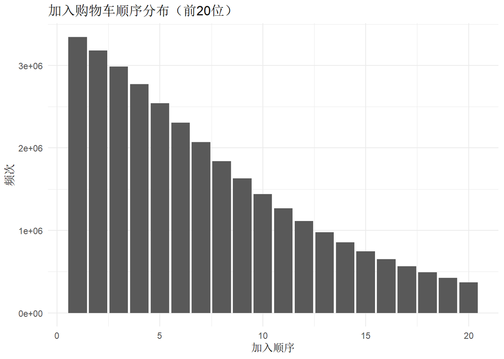

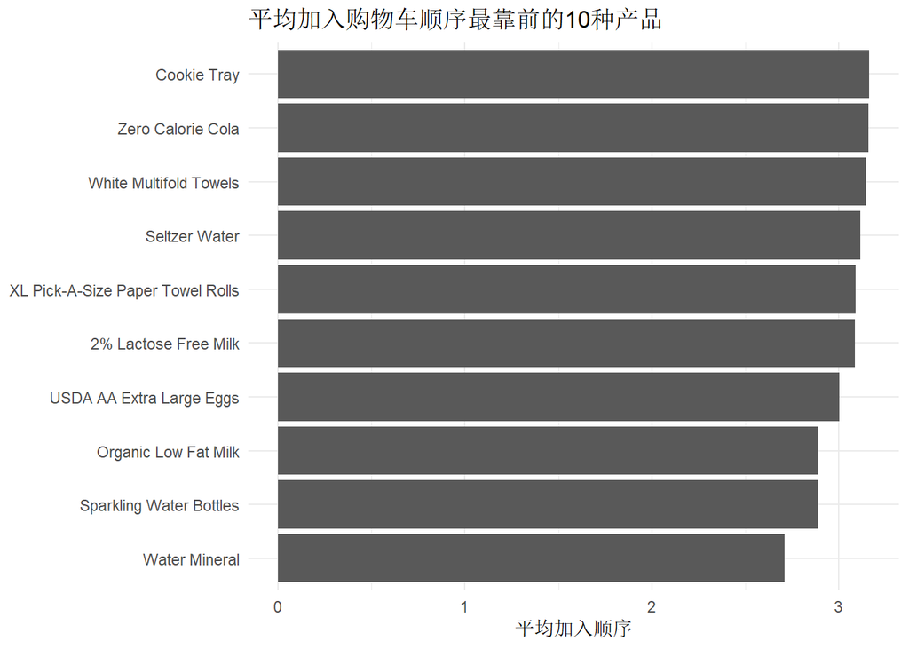

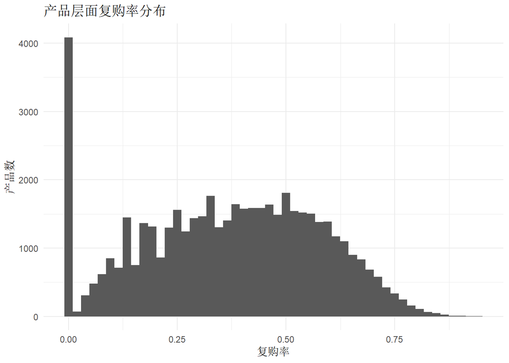

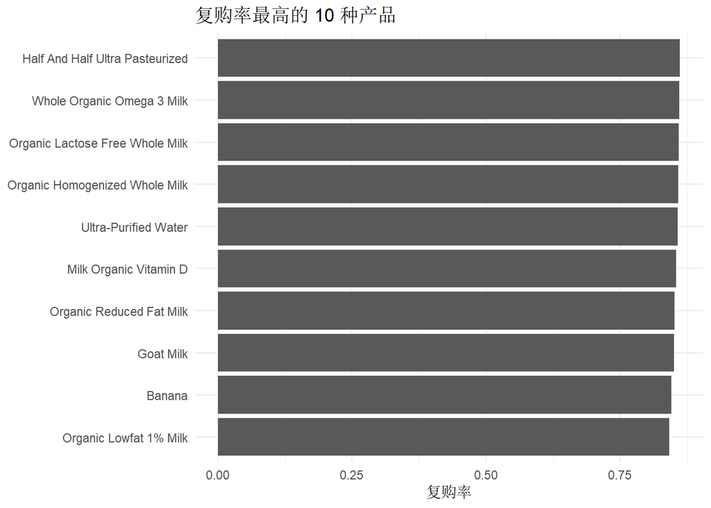

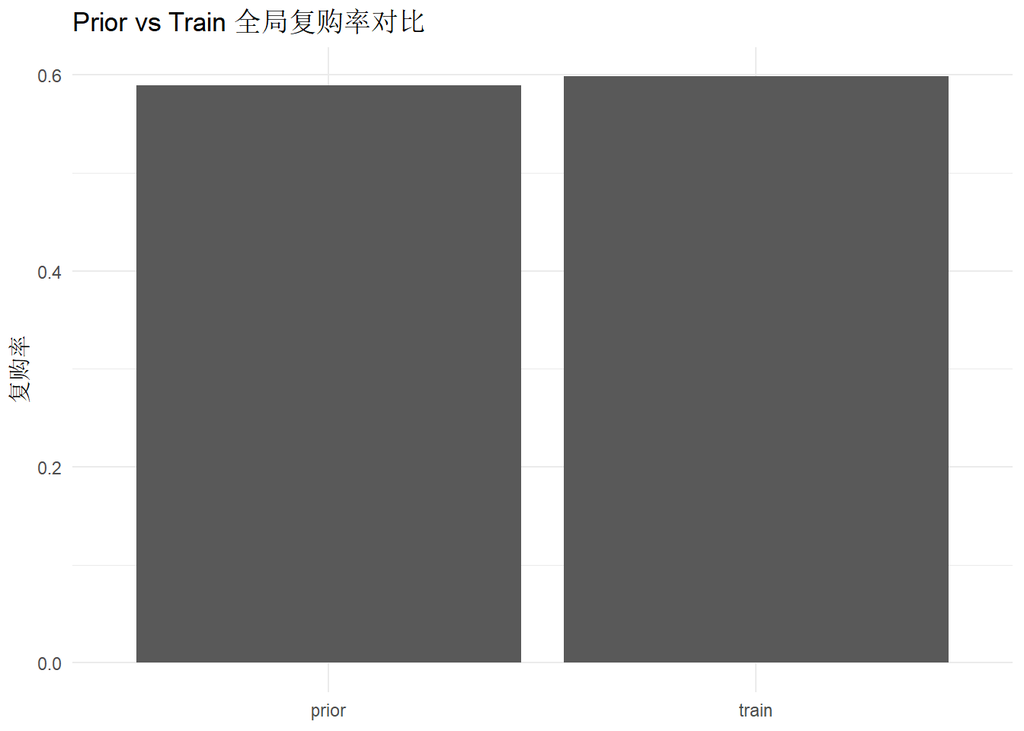

2.3 产品维度 各部门 & 货架产品数

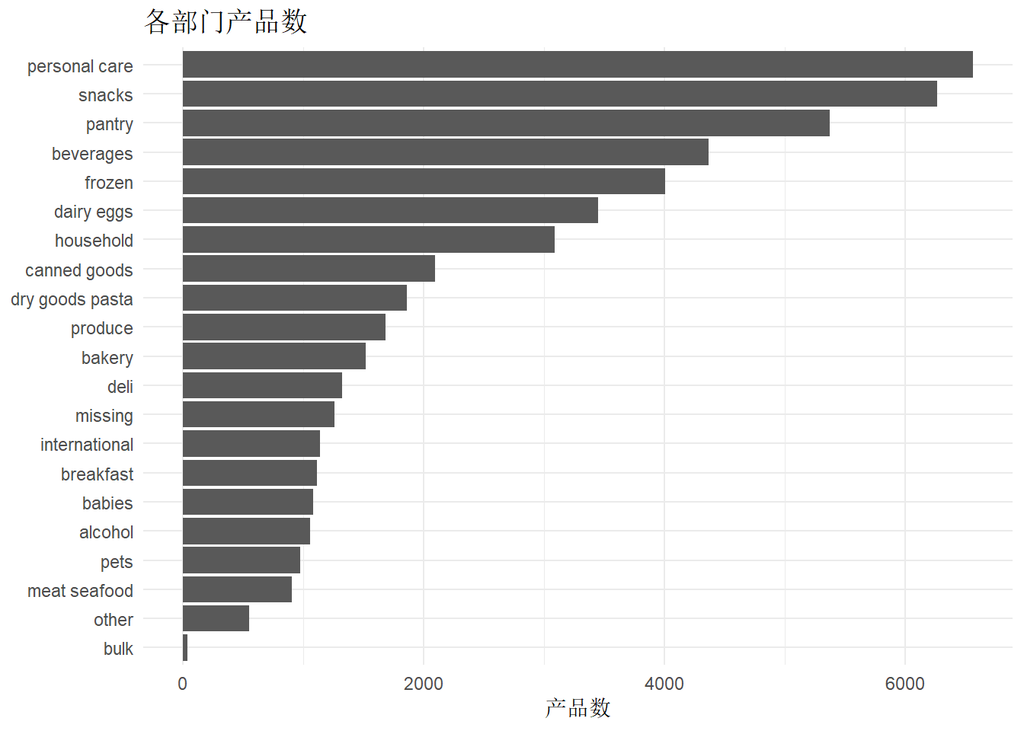

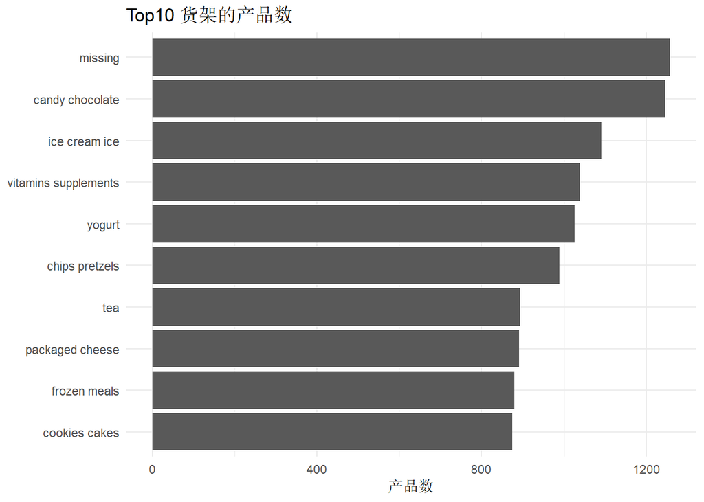

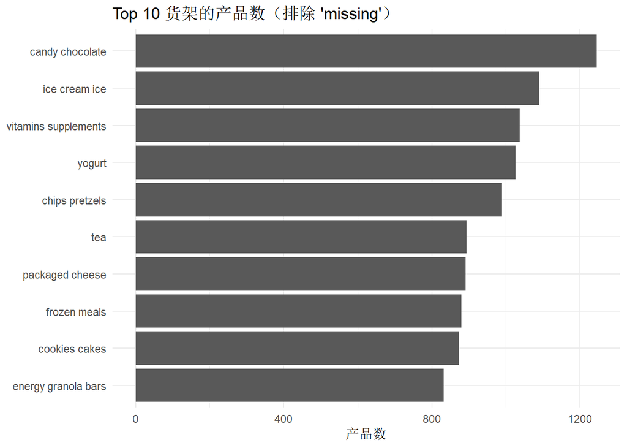

复购率最高 TopN 产品

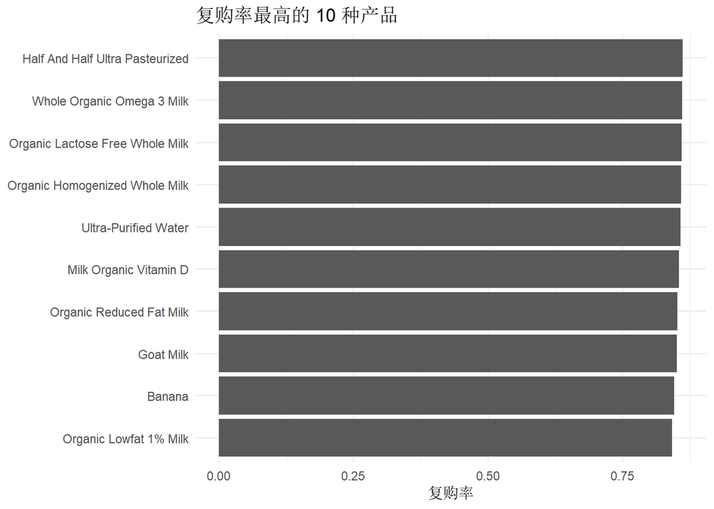

3.2 用户购买行为分群（RFM）

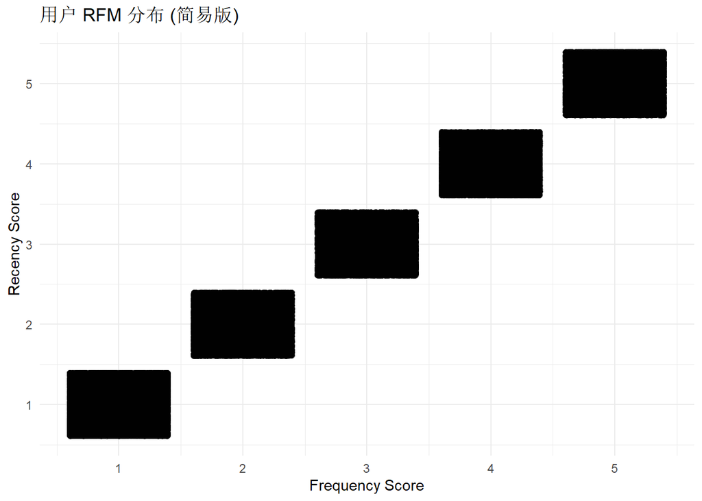

RFM 基础知识 Recency (R)新近度 (R)：距离客户上次下单的时间。

Frequency (F) 频率 (F)：他们总共下单了多少单。

(Monetary (M) is left out here because we don’t have $-value fields.)

综合起来，RFM 用于识别以下群体：

R-score F-score Who these are High High Champions (最佳!) High Low New or About-to-Sleep 新客户或即将入驻（有时高新近度仅指首次下单） Low High Loyal but Inactive 忠诚但不活跃（过去经常购买，但最近没有） Low Low At Risk or Lost 处于风险或可能会流失

4. 时序与趋势

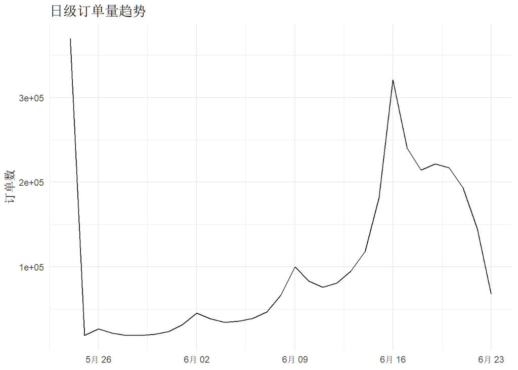

   5 月 26 日左侧的峰值是由于合成 `order_date` 的方式造成的： `orders.csv` 中**实际上没有真正的日历日期**——只有
- `order_dow` (0-6)
- `order_hour_of_day`
- `days_since_prior_order`（上限为 30；不适用于首单） 通过执行 mutate(order_date = today() - days_since_prior_order) 所有 `days_since_prior_order == 30` 的订单（即所有超过 30 天的订单）映射到**一个单一日期**（今天减 30）。这会将数百万行数据集中到该日期，因此会出现巨大的峰值。

如何修复 1. 真实的订单时间戳 - 没有。。。 2. 使用起始日期锚点进行近似 为每个用户的第一个订单选择一个任意的“锚点”日期，然后累计添加 `days_since_prior_order` 偏移量，以重建伪日历 a. 先把每个用户的 NA（首单）当作 0 天间隔。 b. 对每个用户按 order_number 累加这些天数，得到 cum_days。 c. 假设「最后一次下单」对应今天（或一个指定的固定日期），则锚点 anchor_date = today() − max(cum_days) d. 最终日期 = anchor_date + cum_days。

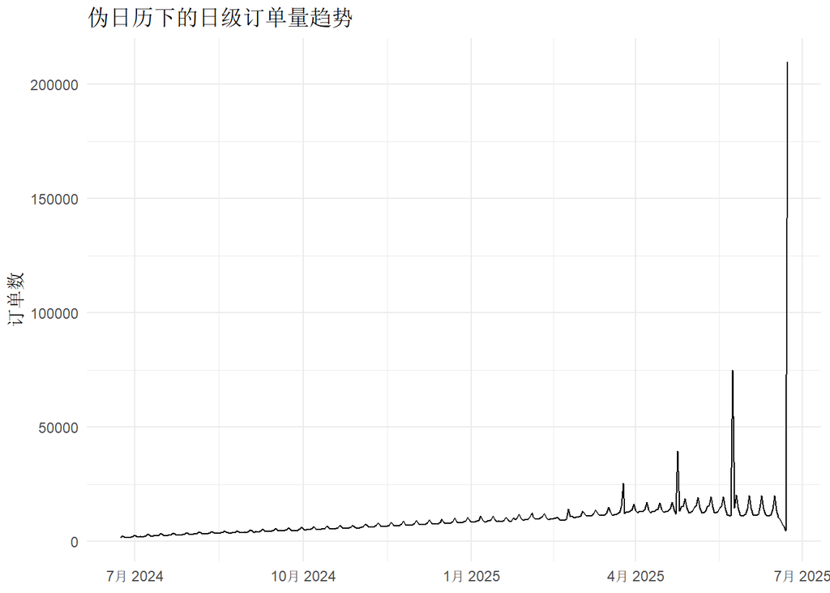

锚定“上次订单 = 今天”会导致不正常的峰值 （不可行）

两种更简单的替代方案 A) 绘制 相对时间轴

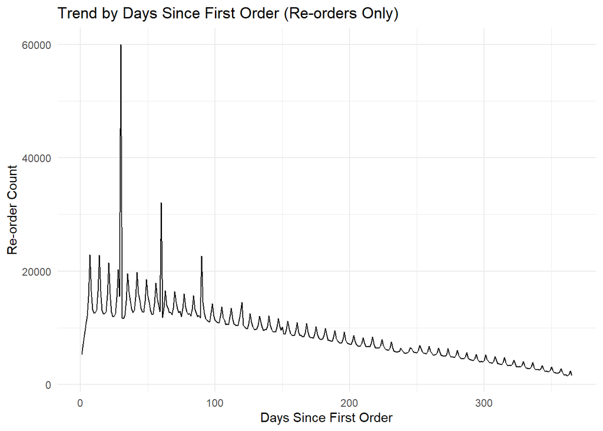

2. 锚定到**中点**或人为设定的“开始日期”

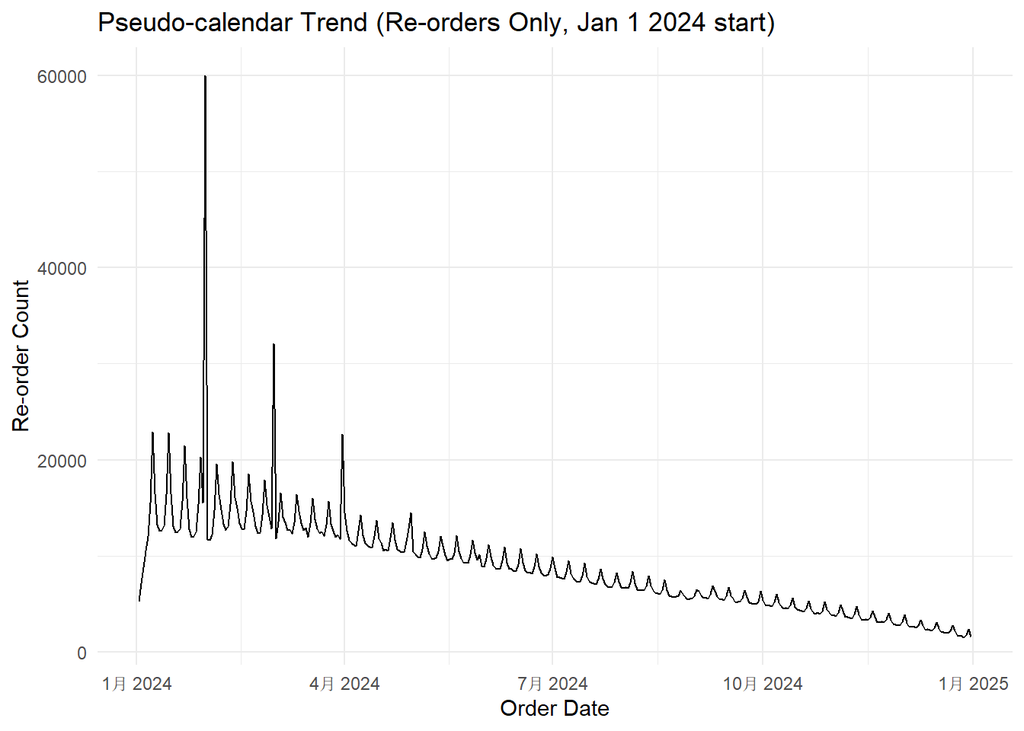

这两张图展示的是每个用户在首次下单以后各个“天”上的复购次数，只统计了cum_days > 0（也就是第二次及以后的订单），从而剔除了那条“所有人首单集中在 0 天” 的巨大峰值

价值与应用

周期性促销：可以针对“每周复购”的人群设计周期性营销（例如 7 日回购提醒）。 生命周期管理：根据复购衰减曲线，识别“流失高风险期”（比如第 20–30 天）并推送激励。 数据校准：30 天截断峰提醒我们，用此字段做时间分析时要小心截断偏差；如果需要，更细粒度的天数数据会更准确。 数据限制提示：峰值都是“≥30 天”打包，因此无法区分真实是 31 天还是 90 天，只能看到“至少一个月”这个分段的强度。

5. 相关性与聚类

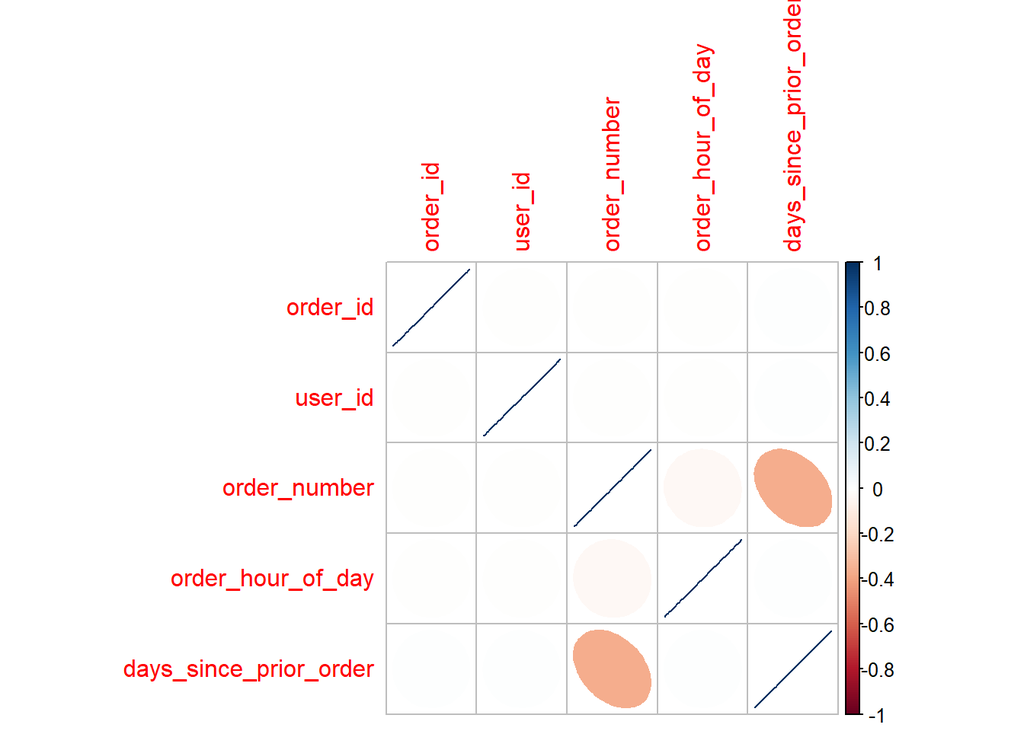

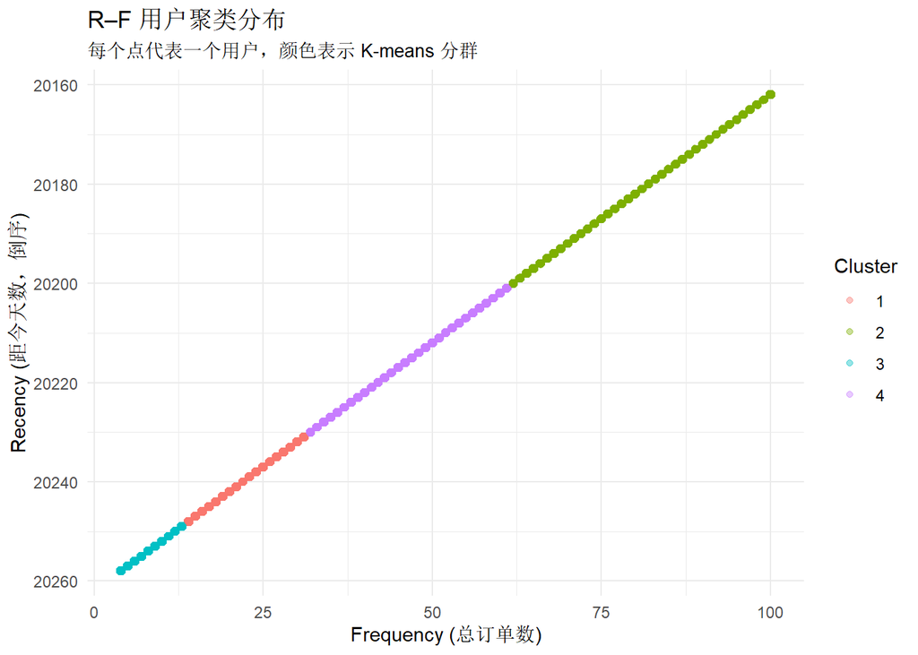

之前的RFM是用分位数分箱 (ntile) 的方法绘制 R 和 F 网格 按新近度对用户进行排序，并为每个指标将其划分为 **5 个大小相等的桶**（分位数），然后绘制 R_score 与 F_score 的关系图。 **优点：**非常透明且易于解释（“此单元格是最近前 20% 的数据，也是最常出现的前 20% 的数据”）。 **缺点：** 1.即使数据分布不平衡，也会在第 20、40、60、80 个百分位数处施加**严格的截断**。 2.不考虑联合分布的“形状”；单独处理每个轴。

K 均值聚类 — “基于距离的细分” 将两个指标标准化（均值 0，标准差 1），然后运行 K 均值聚类将用户划分为 **4 个聚类**，以最小化二维 R-F 空间中的聚类内方差。 **输出：** 四个组，每个组都有各自的质心（例如“高频/高频”、“低频/中频”等）。 **优点：** 1.聚类基于**实际数据密度**和自然分组，而非任意百分位数。 2.可以根据业务需求选择任意数量的聚类。 **缺点：** 1.如果利益相关者期望“前 20% = VIP”的逻辑，则更难解释。 2.必须事后解释每个聚类的含义（例如，聚类 1 =“新手”，聚类 2 =“潜在高消费用户”）。

如果认为客户构成是**自然群体**（例如，与 20% 的削减不一致的中频“最佳点”），并且希望数据能够驱动细分定义，那么**K 均值**会是更好的选择。

散点图“太”线性了，因为**新近度**计算方式是：recency = as.numeric(today() - max(order_number)) 实际上，它的作用是 recency_i = today() - (用户 i 的最高 order_number) 所以，如果用户 i 下了 50 个订单，就是在执行 `today() - 50`——订单数量和“新近度”之间完美的一一对应关系，因此是直线对角线

修复“最近成交量”→使用自上次订单以来的实际天数

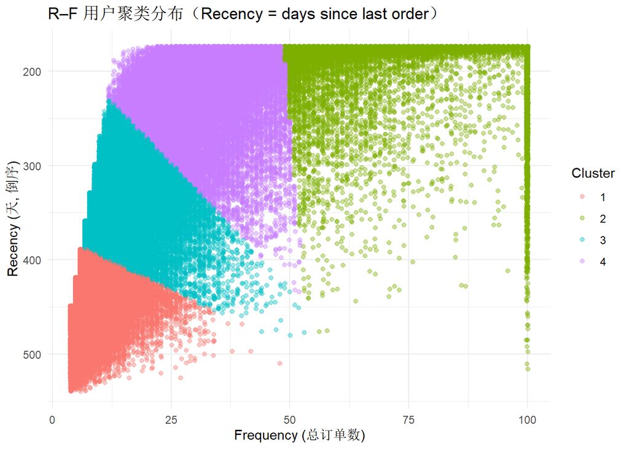

1. **`order_date` 是一个真正的日历日期**（尽管是伪日历），通过累计真实的 `days_since_prior_order` 偏移量。
2. **`recency = today() - max(order_date)`** 现在衡量的是自用户上次下单以来的实际天数。
3. 由于 **频率**（订单总数）和 **新近度**（自上次下单以来的天数）现在是 **两个独立的真实世界信号**，因此它们之间不存在强制的线性关系。